# lab_session_01

## Make a predictive model

After this brief exploration of the dataset, let's try to train a model to predict the survival of "new" (i.e. unknown) passengers.

A *decision tree* classifier will be used to complete this task.

To begin with, import the decision tree package (named `tree`) implemented in Scikit Learn (a.k.a. `sklearn`).

```python
import sklearn.tree
```

Then reload the dataset:

```python
titanic = pd.read_csv("https://raw.githubusercontent.com/adimajo/CSE204-2021/master/data/titanic_train.csv")
```

### Exercise 8

Based on investigations made in the exploratory analysis, which variables should be removed from the dataset? Complete the following cell to remove useless data.

```python
### BEGIN SOLUTION
titanic = titanic.drop(['Name', 'Ticket', 'Cabin', 'PassengerId'], axis=1)
### END SOLUTION
```

```python
### BEGIN HIDDEN TESTS
titanic_bis = pd.read_csv("https://raw.githubusercontent.com/adimajo/CSE204-2021/master/data/titanic_train.csv")
titanic_bis = titanic_bis.drop(['Name', 'Ticket', 'Cabin', 'PassengerId'], axis=1)
pd.testing.assert_frame_equal(titanic, titanic_bis)
### END HIDDEN TESTS
```

Once you have removed useless variables, remove examples with missing values from the dataset.

```python
### BEGIN SOLUTION
titanic = titanic.dropna()
### END SOLUTION
```

```python
### BEGIN HIDDEN TESTS
pd.testing.assert_frame_equal(titanic, titanic_bis.dropna())
### END HIDDEN TESTS
```

Let's finish the dataset cleaning by converting categorical features to numerical ones.

```python
titanic['Embarked'] = titanic['Embarked'].map({'S': 0, 'C': 1, 'Q': 2}).astype(int)
titanic['Sex'] = titanic['Sex'].map({'male': 0, 'female': 1}).astype(int)
```

The following cell gives an overview of our dataset (only the first lines displayed).

```python
titanic.head()
```

|  | Survived | Pclass | Sex | Age | SibSp | Parch | Fare | Embarked |
| --- | --- | --- | --- | --- | --- | --- | --- | --- |
| 0 | 0 | 3 | 0 | 22.0 | 1 | 0 | 7.2500 | 0 |
| 1 | 1 | 1 | 1 | 38.0 | 1 | 0 | 71.2833 | 1 |
| 2 | 1 | 3 | 1 | 26.0 | 0 | 0 | 7.9250 | 0 |
| 3 | 1 | 1 | 1 | 35.0 | 1 | 0 | 53.1000 | 0 |
| 4 | 0 | 3 | 0 | 35.0 | 0 | 0 | 8.0500 | 0 |

Now that the dataset is ready, we split it in two subsets:

- the training set (`X_train` and `Y_train`)
- the testing set (`X_test` and `Y_test`)

`X_xxx` contains example's *features* and `Y_xxx` contains example's *labels*

```python
X = titanic.drop("Survived", axis=1)
Y = titanic["Survived"]

X_train = X.iloc[:-10]
Y_train = Y.iloc[:-10]

X_test = X.iloc[-10:]
Y_test = Y.iloc[-10:]

X_train.shape, Y_train.shape, X_test.shape, Y_test.shape
```

```
((702, 7), (702,), (10, 7), (10,))
```

### Exercise 9

Explain why is it necessary to split the dataset in these two subsets (training set and testing set)?

The most important task of our model is to be able to generalize predictions on new examples, not to be excellent on the training dataset. Thus we should evaluate it with data it has not used for the training.

The classifier is made and trained with the following code:

```python
decision_tree = sklearn.tree.DecisionTreeClassifier()

decision_tree.fit(X_train, Y_train)
```

```
DecisionTreeClassifier()
```

Then the success rate of predictions is checked on both sets:

```python
decision_tree.score(X_train, Y_train)
```

```
0.9857549857549858
```

```python
decision_tree.score(X_test, Y_test)
```

```
0.9
```

Finally we make some predictions and compare them to the truth:

```python
Y_pred = decision_tree.predict(X_test)

pd.DataFrame(np.array([Y_pred, Y_test]).T, columns=('Predicted', 'Actual'))
```

|  | Predicted | Actual |
| --- | --- | --- |
| 0 | 1 | 1 |
| 1 | 0 | 0 |
| 2 | 0 | 0 |
| 3 | 0 | 0 |
| 4 | 0 | 0 |
| 5 | 0 | 0 |
| 6 | 0 | 0 |
| 7 | 1 | 1 |
| 8 | 0 | 1 |
| 9 | 0 | 0 |

### Plot feature importances (for the trained model)

The following code plot the relative importance of features for the prediction task (for the trained model).

```python
imp = pd.DataFrame(decision_tree.feature_importances_,
                   index=X_train.columns,
                   columns=['Importance'])
imp.sort_values(['Importance'], ascending=False)
```

|  | Importance |
| --- | --- |
| Sex | 0.300708 |
| Age | 0.280845 |
| Fare | 0.195755 |
| Pclass | 0.122585 |
| SibSp | 0.059123 |
| Parch | 0.022376 |
| Embarked | 0.018608 |

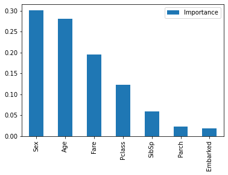

```python
imp.sort_values(['Importance'], ascending=False).plot.bar();
```

### Exercise 10

Compare this list to the assumptions made during the exploratory analysis. Have you predicted a similar ranking?

### Bonus: display the decision tree

```python
import graphviz

dot_data = sklearn.tree.export_graphviz(decision_tree, out_file=None,
                                feature_names=X_train.columns,
                                class_names=['Died', 'Survived'],
                                filled=True, rounded=True,
                                special_characters=True)

graph = graphviz.Source(dot_data, format='png')
```

```python
graph.view()
```

```
'Source.gv.png'
```

# Going further

Here is a good tutorial to complete the lab session: [Understanding and diagnosing your machine-learning models](http://gael-varoquaux.info/interpreting_ml_tuto/) (by Gael Varoquaux)